# Clustering : Classif non supervisée

### 5.3.6 Critère d’arrêt

On va établit un critère d’arrêt pour que l’algorithme soit stoppé quand ce critère d’arrêt est atteint, au lieu de devoir définir un nombre préalable d’itérations, pouvant être soit : - trop grand (dans ce cas l’algorithme continue à calculer les estimations des paramètres à chaque itérations alors que la convergence aurait été atteinte), ce qui perd du temps et utilise inutilement de la puissance computationnelle - ou trop petit (dans ce cas, l’algorithme s’arrête avant la convergence qui aurait eu lieu avec un nombre plus grand d’itérations), donc les paramètres les plus vraimsemblables des deux gaussiennes ne sont pas estimées.

On va définir comme critère d’arrêt que le log de la vraisemblance soit maximisé.

```r
etapesEM_autostopped <- function (vec, mu1.init = mu1.1, mu2.init = mu2.1, s1.init = s1.1, s2.init = s2.1 ) {

  num_iter <- 1
  loglik <- NULL

  # initialisation
  resE <- etapeE(vec, mu1.1, mu2.1, s1.1, s2.1)
  resM <- etapeM(vec, matrice = resE[[1]])

  loglik[num_iter] <- sum(log(resE[[2]] * dnorm(vec, resM[[2]], resM[[4]]) +
                        resE[[3]] * dnorm(vec, resM[[3]], resM[[5]])))

  cat("Étape", num_iter, ": mu1 =", round(resM[[2]]), "| mu2 =", round(resM[[3]]),
      "| s1 =", round(resM[[4]]), "| s2 =", round(resM[[5]]),
      "| Log-Vraisemblance =", round(loglik[num_iter], 4), "\n")

    # Boucle d'itération EM
  repeat {
    num_iter <- num_iter + 1

    resE <- etapeE(vec, resM[[2]], resM[[3]], resM[[4]], resM[[5]])
    resM <- etapeM(vec, matrice = resE[[1]])

    loglik[num_iter] <- sum(log(resE[[2]] * dnorm(vec, resM[[2]], resM[[4]]) +
                                resE[[3]] * dnorm(vec, resM[[3]], resM[[5]])))

    cat("Étape", num_iter, ": mu1 =", round(resM[[2]]), "| mu2 =", round(resM[[3]]),
        "| s1 =", round(resM[[4]]), "| s2 =", round(resM[[5]]),
        "| Log-Vraisemblance =", round(loglik[num_iter], 4), "\n")

    # condition d'arrêt
    if (loglik[num_iter] <= loglik[num_iter - 1]) {
      cat("\nArrêt automatique (plus d'amélioration de la log-vraisemblance)\n")
      break
    }
  }

}
```

On test la variabilité du résultat avec des valeurs d’initialisation différentes.

```r
etapesEM_autostopped(vec)
```

```
## Étape 1 : mu1 = 14 | mu2 = 25 | s1 = 5 | s2 = 8 | Log-Vraisemblance = -1658.415
## Étape 2 : mu1 = 13 | mu2 = 24 | s1 = 5 | s2 = 7 | Log-Vraisemblance = -1653.853
## Étape 3 : mu1 = 13 | mu2 = 24 | s1 = 4 | s2 = 7 | Log-Vraisemblance = -1651.834
## Étape 4 : mu1 = 13 | mu2 = 24 | s1 = 4 | s2 = 7 | Log-Vraisemblance = -1651.023
## Étape 5 : mu1 = 13 | mu2 = 24 | s1 = 4 | s2 = 6 | Log-Vraisemblance = -1650.799
## Étape 6 : mu1 = 13 | mu2 = 24 | s1 = 4 | s2 = 6 | Log-Vraisemblance = -1650.672
## Étape 7 : mu1 = 13 | mu2 = 24 | s1 = 4 | s2 = 6 | Log-Vraisemblance = -1650.623
## Étape 8 : mu1 = 13 | mu2 = 24 | s1 = 4 | s2 = 6 | Log-Vraisemblance = -1650.647
##
## Arrêt automatique (plus d'amélioration de la log-vraisemblance)
```

```r
etapesEM_autostopped(vec, mu1.init = 17 , mu2.init = 25,s1.init = 0 , s2.init = 5)
```

```
## Étape 1 : mu1 = 14 | mu2 = 25 | s1 = 5 | s2 = 8 | Log-Vraisemblance = -1658.415
## Étape 2 : mu1 = 13 | mu2 = 24 | s1 = 5 | s2 = 7 | Log-Vraisemblance = -1653.853
## Étape 3 : mu1 = 13 | mu2 = 24 | s1 = 4 | s2 = 7 | Log-Vraisemblance = -1651.834
## Étape 4 : mu1 = 13 | mu2 = 24 | s1 = 4 | s2 = 7 | Log-Vraisemblance = -1651.023
## Étape 5 : mu1 = 13 | mu2 = 24 | s1 = 4 | s2 = 6 | Log-Vraisemblance = -1650.799
## Étape 6 : mu1 = 13 | mu2 = 24 | s1 = 4 | s2 = 6 | Log-Vraisemblance = -1650.672
## Étape 7 : mu1 = 13 | mu2 = 24 | s1 = 4 | s2 = 6 | Log-Vraisemblance = -1650.623
## Étape 8 : mu1 = 13 | mu2 = 24 | s1 = 4 | s2 = 6 | Log-Vraisemblance = -1650.647
##
## Arrêt automatique (plus d'amélioration de la log-vraisemblance)
```

```r
etapesEM_autostopped(vec, mu1.init = 13 , mu2.init = 17,s1.init = 0.5 , s2.init = 0)
```

```
## Étape 1 : mu1 = 14 | mu2 = 25 | s1 = 5 | s2 = 8 | Log-Vraisemblance = -1658.415
## Étape 2 : mu1 = 13 | mu2 = 24 | s1 = 5 | s2 = 7 | Log-Vraisemblance = -1653.853
## Étape 3 : mu1 = 13 | mu2 = 24 | s1 = 4 | s2 = 7 | Log-Vraisemblance = -1651.834
## Étape 4 : mu1 = 13 | mu2 = 24 | s1 = 4 | s2 = 7 | Log-Vraisemblance = -1651.023
## Étape 5 : mu1 = 13 | mu2 = 24 | s1 = 4 | s2 = 6 | Log-Vraisemblance = -1650.799
## Étape 6 : mu1 = 13 | mu2 = 24 | s1 = 4 | s2 = 6 | Log-Vraisemblance = -1650.672
## Étape 7 : mu1 = 13 | mu2 = 24 | s1 = 4 | s2 = 6 | Log-Vraisemblance = -1650.623
## Étape 8 : mu1 = 13 | mu2 = 24 | s1 = 4 | s2 = 6 | Log-Vraisemblance = -1650.647
##
## Arrêt automatique (plus d'amélioration de la log-vraisemblance)
```

```r
# même avec d'autres valeurs d'initialisation
```

Vérification

```r
x <- f(13,25,4,6, 400,100)
```

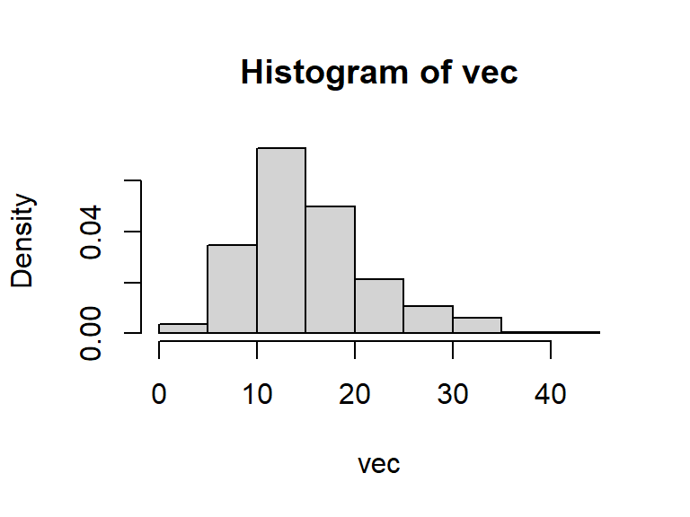

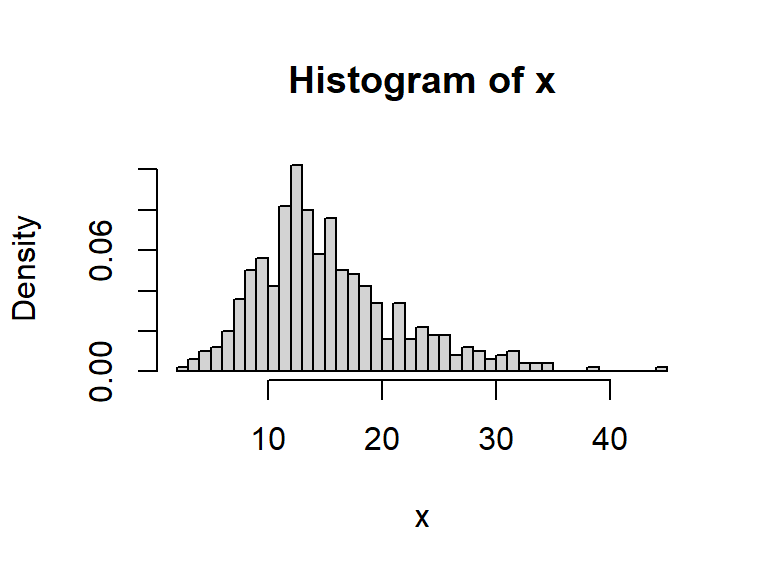

```r
hist(x, freq = F, nclass = 50)
```

Test avec notre vecteur généré pour un autre groupe (res)

```r
etapesEM_autostopped(vec = res, mu1.init = 0 , mu2.init = 12, s1.init =1 , s2.init = 2)
```

```
## Étape 1 : mu1 = 5 | mu2 = 1 | s1 = 5 | s2 = 5 | Log-Vraisemblance = -1552.875
## Étape 2 : mu1 = 7 | mu2 = 2 | s1 = 6 | s2 = 4 | Log-Vraisemblance = -1541.846
## Étape 3 : mu1 = 8 | mu2 = 2 | s1 = 5 | s2 = 4 | Log-Vraisemblance = -1532.714
## Étape 4 : mu1 = 8 | mu2 = 1 | s1 = 5 | s2 = 3 | Log-Vraisemblance = -1515.858
## Étape 5 : mu1 = 9 | mu2 = 1 | s1 = 5 | s2 = 3 | Log-Vraisemblance = -1486.722
## Étape 6 : mu1 = 9 | mu2 = 0 | s1 = 4 | s2 = 2 | Log-Vraisemblance = -1450.638
## Étape 7 : mu1 = 10 | mu2 = 0 | s1 = 3 | s2 = 2 | Log-Vraisemblance = -1430.314
## Étape 8 : mu1 = 10 | mu2 = 0 | s1 = 3 | s2 = 2 | Log-Vraisemblance = -1426.283
## Étape 9 : mu1 = 10 | mu2 = 0 | s1 = 3 | s2 = 2 | Log-Vraisemblance = -1425.756
## Étape 10 : mu1 = 10 | mu2 = 0 | s1 = 3 | s2 = 2 | Log-Vraisemblance = -1425.649
## Étape 11 : mu1 = 10 | mu2 = 0 | s1 = 3 | s2 = 2 | Log-Vraisemblance = -1425.62
## Étape 12 : mu1 = 10 | mu2 = 0 | s1 = 3 | s2 = 2 | Log-Vraisemblance = -1425.612
## Étape 13 : mu1 = 10 | mu2 = 0 | s1 = 3 | s2 = 2 | Log-Vraisemblance = -1425.61
## Étape 14 : mu1 = 10 | mu2 = 0 | s1 = 3 | s2 = 2 | Log-Vraisemblance = -1425.61
## Étape 15 : mu1 = 10 | mu2 = 0 | s1 = 3 | s2 = 2 | Log-Vraisemblance = -1425.61
## Étape 16 : mu1 = 10 | mu2 = 0 | s1 = 3 | s2 = 2 | Log-Vraisemblance = -1425.61
## Étape 17 : mu1 = 10 | mu2 = 0 | s1 = 3 | s2 = 2 | Log-Vraisemblance = -1425.61
## Étape 18 : mu1 = 10 | mu2 = 0 | s1 = 3 | s2 = 2 | Log-Vraisemblance = -1425.61
## Étape 19 : mu1 = 10 | mu2 = 0 | s1 = 3 | s2 = 2 | Log-Vraisemblance = -1425.61
## Étape 20 : mu1 = 10 | mu2 = 0 | s1 = 3 | s2 = 2 | Log-Vraisemblance = -1425.61
## Étape 21 : mu1 = 10 | mu2 = 0 | s1 = 3 | s2 = 2 | Log-Vraisemblance = -1425.61
## Étape 22 : mu1 = 10 | mu2 = 0 | s1 = 3 | s2 = 2 | Log-Vraisemblance = -1425.61
## Étape 23 : mu1 = 10 | mu2 = 0 | s1 = 3 | s2 = 2 | Log-Vraisemblance = -1425.61
## Étape 24 : mu1 = 10 | mu2 = 0 | s1 = 3 | s2 = 2 | Log-Vraisemblance = -1425.61
## Étape 25 : mu1 = 10 | mu2 = 0 | s1 = 3 | s2 = 2 | Log-Vraisemblance = -1425.61
## Étape 26 : mu1 = 10 | mu2 = 0 | s1 = 3 | s2 = 2 | Log-Vraisemblance = -1425.61
## Étape 27 : mu1 = 10 | mu2 = 0 | s1 = 3 | s2 = 2 | Log-Vraisemblance = -1425.61
## Étape 28 : mu1 = 10 | mu2 = 0 | s1 = 3 | s2 = 2 | Log-Vraisemblance = -1425.61
## Étape 29 : mu1 = 10 | mu2 = 0 | s1 = 3 | s2 = 2 | Log-Vraisemblance = -1425.61
## Étape 30 : mu1 = 10 | mu2 = 0 | s1 = 3 | s2 = 2 | Log-Vraisemblance = -1425.61
## Étape 31 : mu1 = 10 | mu2 = 0 | s1 = 3 | s2 = 2 | Log-Vraisemblance = -1425.61
## Étape 32 : mu1 = 10 | mu2 = 0 | s1 = 3 | s2 = 2 | Log-Vraisemblance = -1425.61
##
## Arrêt automatique (plus d'amélioration de la log-vraisemblance)
```

### 5.3.7 Conclusion

# 6 Seance 5

## 6.1 Introduction

Dans les modèles à variables latentes, on suppose que chaque observation $X_i$ provient d’une **classe cachée** (ou variable latente) notée $Z_i$.

On considère que : $Z_i \sim \text{Multinomial}(\pi_1, \ldots, \pi_K)$

où :

- $K$ est le nombre de classes (ou composantes du mélange),
- $\pi_k$ est la probabilité d’appartenir à la classe $k$, avec :

$$\sum_{k=1}^K \pi_k = 1$$

- $Z_{ik} = 1$ si l’individu $i$ appartient à la classe $k$, sinon $Z_{ik} = 0$.

## 6.2 Étape 1 : Modélisation probabiliste

L’objectif de cette première étape est de **décrire le mécanisme probabiliste** qui permet de générer les observations lorsque l’on suppose l’existence d’une **variable latente** indiquant l’appartenance de chaque individu à une classe cachée.  
Cette variable latente représente l’idée que les données proviennent d’un **mélange de plusieurs sous-populations**, chacune ayant ses propres caractéristiques statistiques.

Ainsi, le modèle repose sur deux éléments essentiels :

1. **la probabilité d’appartenir à chaque classe**, définie par les poids du mélange ;
2. **la distribution des observations conditionnellement à cette classe**, ici modélisée par une loi gaussienne.

### 6.2.1 Distribution de la variable latente

On introduit une variable latente $Z$, souvent représentée comme un vecteur binaire $(Z_1, \ldots, Z_K)$, où :

- $Z_k = 1$ signifie que l’individu appartient à la classe $k$,
- $Z_k = 0$ signifie qu’il n’y appartient pas.

Une seule composante est égale à 1, les autres valent 0 : l’individu appartient **exactement à une seule classe**.

La variable $Z$ suit donc une **loi multinomiale à un seul tirage**, paramétrée par les poids $\pi_k$.  
Les $\pi_k$ représentent les proportions de chaque classe dans la population :

$$p(z) = \prod_{k=1}^{K} \pi_k^{z_k}$$

Cette écriture compacte traduit le fait que :

- si $z_k = 1$, on récupère $\pi_k$,
- sinon, $\pi_k^{0} = 1$ et n’influence pas la probabilité.

Ainsi, la distribution de $Z$ modélise **la structure invisible** qui génère les données.

### 6.2.2 Distribution conditionnelle : comment générer une observation $x$ ?

Une fois la classe latente déterminée, l’observation $x$ est générée selon une distribution propre à cette classe.

On suppose que chaque classe $k$ suit une loi normale multivariée :

- moyenne $\mu_k$,
- matrice de covariance $\Sigma_k$.

Autrement dit : $p(x \mid z_k = 1) = \mathcal{N}(x \mid \mu_k, \Sigma_k)$

Si l’on considère l’expression en fonction du vecteur $z$, on peut écrire :

$$p(x \mid z)
=
\prod_{k=1}^K
\mathcal{N}(x \mid \mu_k, \Sigma_k)^{z_k}$$

Cette forme s’interprète exactement comme pour $p(z)$ :

- seule la gaussienne correspondant à la classe active ($z_k = 1$) intervient,
- les autres termes, élevés à la puissance 0, disparaissent.

### 6.2.3 Distribution marginale de $x$ : le mélange gaussien

Comme la variable latente n’est pas observée, on s’intéresse à la probabilité marginale d’obtenir $x$.  
On somme donc sur toutes les configurations possibles de $z$.  
Cela conduit naturellement au modèle de **mélange de gaussiennes** :

$$p(x)
=
\sum_{z} p(z) \,* \ p(x \mid z)
=
\sum_{k=1}^K \pi_k \, \mathcal{N}(x \mid \mu_k, \Sigma_k)$$

Cette expression montre que la distribution globale des données est une **combinaison pondérée** des distributions de chaque classe.

- Les $\pi_k$ pondèrent l’importance relative de chaque composante.
- Les **gaussiennes** $\mathcal{N}(x \mid \mu_k, \Sigma_k)$ décrivent les profils propres aux sous-populations.

C’est ce modèle qui sera estimé par l’algorithme EM dans les étapes suivantes.

## 6.3 Étape 2 : Expectation (E-step)

L’objectif de l’étape E est de calculer, pour chaque observation $x$, la **probabilité a posteriori** qu’elle appartienne à chacune des $K$ composantes du mélange.

On note :

$$\gamma(z_k) = p(z_k = 1 \mid x)$$

Cela représente la probabilité pour que l’individu $x$ appartienne à la classe $k$.

### 6.3.1 Application du théorème de Bayes

Comme $Z_k$ indique l’appartenance à la classe $k$, on applique le théorème de Bayes :

$$p(z_k = 1 \mid x)
=
\frac{
p(x \mid z_k = 1) \, p(z_k = 1)
}{
\sum_{j=1}^K p(x \mid z_j = 1) \, p(z_j = 1)
}$$

Dans un modèle de mélange gaussien, on a :

- $p(z_k = 1) = \pi_k$, le poids de la composante $k$,
- $p(x \mid z_k = 1) = \mathcal{N}(x \mid \mu_k, \Sigma_k)$, la gaussienne associée à la classe $k$.

On obtient alors :

$$\gamma(z_k)
=
p(z_k = 1 \mid x)
=
\frac{
\pi_k \, \mathcal{N}(x \mid \mu_k, \Sigma_k)
}{
\sum_{j=1}^K \pi_j \, \mathcal{N}(x \mid \mu_j, \Sigma_j)
}$$

Cette étape correspond à l’**étiquetage probabiliste** (soft asignment) :

- si $\gamma(z_k)$ est proche de 1 → l’observation appartient presque sûrement à la classe $k$,
- si les $\gamma(z_k)$ sont proches pour plusieurs $k$ → l’observation est « entre » différentes classes.
- pour un individu i $\sum^{K}_{k=1} \gamma{(z_{ik})} = 1$

## 6.4 Étape 3 : Maximisation (M-step) — mise à jour des paramètres

L’objectif de l’étape M est de maximiser la **log-vraisemblance** du modèle en utilisant les $\gamma(z_{ik})$ calculées à l’étape E.  
On met à jour les paramètres du mélange gaussien : $\pi_k, \mu_k, \Sigma_k$.

### 6.4.1 Log-vraisemblance

La log-vraisemblance s’écrit :

$$\ln p(\mathbf{X} \mid \boldsymbol{\pi}, \boldsymbol{\mu},
\boldsymbol{\Sigma})
=
\sum_{i=1}^{n}
\ln \left\{
\sum_{k=1}^{K}
\pi_k \, \mathcal{N}(X_i \mid \mu_k, \Sigma_k)
\right\}$$

### 6.4.2 Définition du nombre effectif d’observations par classe

On définit :

$$N_k = \sum_{i=1}^n \gamma(z_{ik})$$

Cela correspond au **nombre effectif** d’observations assignées à la classe $k$.

### 6.4.3 Mise à jour des moyennes $\mu_k$

La nouvelle moyenne estimée de chaque composante est :

$$\mu_k^{\text{new}} =
\frac{
\sum_{i=1}^n \gamma(z_{ik}) \, x_i
}{
N_k
}$$

### 6.4.4 Mise à jour des matrices de covariance $\Sigma_k$

La nouvelle matrice de covariance de la classe $k$ s’écrit :

$$\Sigma_k^{\text{new}} =
\frac{
\sum_{i=1}^n \gamma(z_{ik}) (x_i - \mu_k^{\text{new}})(x_i -
\mu_k^{\text{new}})^{T}
}{
N_k
}$$

### 6.4.5 Mise à jour des poids $\pi_k$

Comme les poids doivent vérifier $\sum_{k=1}^K \pi_k = 1$, on maximise la log-vraisemblance sous contrainte à l’aide d’un Lagrangien.  
En dérivant par rapport à $\pi_k$, on obtient :

$$\pi_k^{\text{new}} = \frac{N_k}{n}$$

## 6.5 Application : classification de données fonctionnelles

On s’intéresse ici à la classification de **données fonctionnelles** :  
chaque individu correspond à une **courbe mesurée dans le temps**.

- Chaque ligne représente un spectre ou un signal.
- Chaque colonne correspond à une mesure de ce signal à un instant donné.
- Toutes les courbes sont mesurées avec le **même pas de temps**.

L’objectif est de **classifier ces fonctions** en identifiant des formes ou profils similaires parmi les courbes.

## 6.6 1. Visualisation des courbes

La première étape consiste à **représenter graphiquement l’ensemble des courbes** pour visualiser la variabilité globale, repérer d’éventuels groupes naturels et identifier des ruptures de tendance.

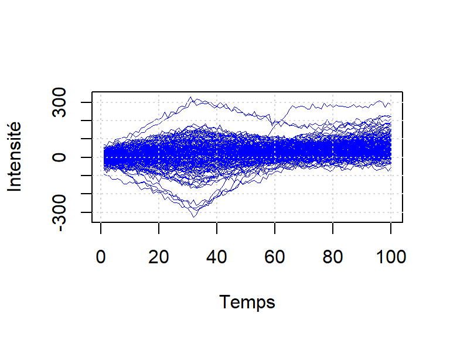

```r
library(tidyverse)

#Importation des données
df <- read.table("data/data2.csv",header=TRUE,sep=";",dec=".")

#Conversion des colonnes en numériques
df[,1:101] <- lapply(df[,1:101],as.numeric)

#Représentation des courbes
matrice_y <- as.matrix(df[,-1]) #on retire la première colonne
t_signal <- t(matrice_y)


seq_t <- seq(1,100,1)

matplot(seq_t,t_signal,type="l",lwd=0.1,col="blue",lty=1,
        xlab= "Temps", ylab ="Intensité")
grid()
```

## 6.7 2. Tentative de classification directe par k-means

Une première idée naturelle est d’appliquer un k-means directement sur les données brutes, en considérant chaque courbe comme un point dans un espace de grande dimension (ici, ~100 dimensions).

Cependant, cette approche fonctionne en général mal pour les données fonctionnelles :

- Les courbes sont très corrélées dans le temps → forte redondance de l’information.
- Le k-means utilise une distance euclidienne standard, peu adaptée à des objets « courbes ».
- Le bruit local ou de petites oscillations peuvent dominer la distance, alors que l’on souhaite capturer plutôt la forme globale (croissance, décroissance, plateau, etc.).

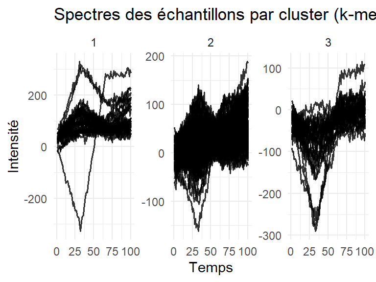

```r
#k-means sur les données brutes

set.seed(123)
res_kmeans <- kmeans(scale(df[,-1]),centers = 3)
cluster_kmeans <- res_kmeans$cluster

df_kmeans <- df %>% mutate(cluster = cluster_kmeans)

dt_long <- df_kmeans %>% pivot_longer(cols = starts_with("V"),
                                      names_to = "temps",
                                      values_to = "intensite")

dt_long$temps <- as.numeric(sub("V", "", dt_long$temps))

# Visualisation des spectres par cluster k-means
ggplot(dt_long, aes(x = temps, y = intensite, group = X)) +
geom_line(alpha = 0.8, linewidth = 0.6) +
facet_wrap(~ cluster, scales = "free_y") +
labs(
title = "Spectres des échantillons par cluster (k-means sur données brutes)",
x = "Temps",
y = "Intensité"
) +
theme_minimal() +
theme(legend.position = "none")
```

On observe que les clusters obtenus sont peu interprétables et ne correspondent pas vraiment aux différence de formes des couches. De plus, entre nous nos 3 clusters n’étaient jamais similaires.

## 6.8 3. Identification de points d’inflexion et modélisation pièce par pièce

En observant les courbes, on remarque que leur structure change à deux instants caractéristiques :

- 1/3 du temps
- 2/3 du temps

Ces points correspondent à des inflexions (changement de tendance : croissance, décroissance). C’est pour cela que nous allons faire une modélisation segment par segment.

L’idée est de résumer chaque segment par un coefficient directeur obtenu via une régression linéaire.

```r
# Séparation des données en 3 segments : 1/3, 2/3 et fin
# (ici colonnes 2:34, 35:67, 68:101 à adapter à la structure réelle)

data_1 <- df[, 2:34]    # segment 1 (33 points)
data_2 <- df[, 35:67]   # segment 2 (33 points)
data_3 <- df[, 68:101]  # segment 3 (34 points)

# Séquences de temps pour chaque segment

seq_1 <- 1:ncol(data_1)   # 1 à 33
seq_2 <- 1:ncol(data_2)   # 1 à 33
seq_3 <- 1:ncol(data_3)   # 1 à 34

# Vecteurs pour stocker les coefficients directeurs

n_ind <- nrow(df_kmeans)
coef_1 <- rep(NA, n_ind)
coef_2 <- rep(NA, n_ind)
coef_3 <- rep(NA, n_ind)

# Boucle des régressions linéaires (lm) pour chaque individu et chaque segment

for (i in 1:n_ind) {

# Segment 1

m1 <- lm(as.numeric(data_1[i, ]) ~ seq_1)
coef_1[i] <- coef(m1)[2]

# Segment 2

m2 <- lm(as.numeric(data_2[i, ]) ~ seq_2)
coef_2[i] <- coef(m2)[2]

# Segment 3

m3 <- lm(as.numeric(data_3[i, ]) ~ seq_3)
coef_3[i] <- coef(m3)[2]
}

# Matrice finale de features (150 x 3 ici)
extraction_features <- as.data.frame(cbind(coef_1, coef_2, coef_3))
colnames(extraction_features) <- c("pente_seg1", "pente_seg2", "pente_seg3")

summary(extraction_features)
```

```
##    pente_seg1        pente_seg2       pente_seg3
##  Min.   :-9.5379   Min.   :-4.472   Min.   :-0.5075
##  1st Qu.:-1.2020   1st Qu.:-1.097   1st Qu.: 0.1212
##  Median : 0.9845   Median : 0.101   Median : 0.3280
##  Mean   : 0.4913   Mean   : 0.550   Mean   : 0.8231
##  3rd Qu.: 2.0200   3rd Qu.: 1.526   3rd Qu.: 1.2052
##  Max.   : 8.9658   Max.   :17.614   Max.   : 4.7376
```

On obtient ainsi une matrice 150 x 3 qui résume chaque courbe par trois nombres représentant les tendances locales.

## 6.9 4. Classification finale des courbes par modèle de mélange gaussien

Une fois ces paramètres extraits, on peut appliquer une méthode de clustering adapté : mclust(), un modèle de mélange gaussien.

```r
library(mclust)

# Modèle de mélange gaussien sur les 3 features

modele_mclust <- Mclust(extraction_features, G = 3)
summary(modele_mclust)
```

```
## ----------------------------------------------------
## Gaussian finite mixture model fitted by EM algorithm
## ----------------------------------------------------
##
## Mclust EEV (ellipsoidal, equal volume and shape) model with 3 components:
##
##  log-likelihood   n df       BIC       ICL
##       -604.2499 150 23 -1323.744 -1352.147
##
## Clustering table:
##  1  2  3
## 70 50 30
```

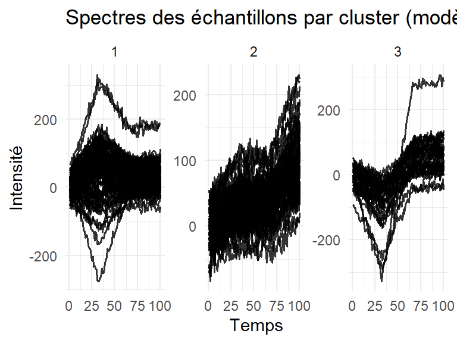

```r
# Classement final des courbes
clusters_mclust <- modele_mclust$classification
extraction_features$cluster_mclust <- as.factor(clusters_mclust)

# On rattache les clusters mclust aux courbes d'origine
df_kmeans$cluster_mclust <- as.factor(clusters_mclust)

# Visualisation des courbes par cluster mclust
dt_long_mclust <- df_kmeans %>%
select(-cluster) %>%        # on peut enlever l'ancien cluster k-means
pivot_longer(
cols = starts_with("V"),
names_to = "temps",
values_to = "intensite"
)

dt_long_mclust$temps <- as.numeric(sub("V", "", dt_long_mclust$temps))

ggplot(dt_long_mclust, aes(x = temps, y = intensite, group = X)) +
geom_line(alpha = 0.8, linewidth = 0.6) +
facet_wrap(~ cluster_mclust, scales = "free_y") +
labs(
title = "Spectres des échantillons par cluster (modèle de mélange gaussien)",
x = "Temps",
y = "Intensité"
) +
theme_minimal() +
theme(legend.position = "none")
```

On obtient ainsi une classification des courbes basée sur leurs profils fonctionnels (pentes des segments), qui est beaucoup mieux interprétables qu’un k-means appliqué directement sur les données brutes.

Le second cluster a une pente positive dans les trois segments tout ayant une amplitude plus faible que le cluster 1.

# 7 Seance 6

## 7.1 Introduction au Topic Modeling

Le topic modeling est une méthode de traitement automatique du langage (NLP) permettant d’explorer de manière non supervisée un ensemble de textes (documents). L’objectif est d’identifier les grands thèmes (topics) présents dans un corpus, chacun étant représenté par une distribution de mots caractéristique.Les topics ne sont pas connus à l’avance.

Le cadre théorique le plus utilisé pour cela est le modèle LDA (Latent Dirichlet Allocation), proposé par Blei et al.

## 7.2 Définir l’objet statistique : le document

Première question clé : comment modélise-t-on un document ?

Dans LDA, un document est représenté comme un mélange de plusieurs topics, chaque topic contribuant avec une proportion différente. Un document n’est pas rattaché à un seul topic, mais plutôt à une distribution de topics.

- Chaque topic est lui-même une distribution de mots.
- Chaque document possède sa propre distribution de topics.
- Un même mot peut être généré par différents topics selon sa probabilité d’appartenance.

Cette conception est comparable à un modèle de mélange (comme le mélange gaussien) mais ici les composantes sont des distributions de mots et non des distributions continues.

## 7.3 Le processus génératif d’un document (LDA)

Pour comprendre comment la machine retrouve les topics, il faut repartir du processus génératif :  
on cherche à comprendre comment un document pourrait être généré si les topics existaient déjà.

LDA repose sur un modèle hiérarchique à trois niveaux :

$$\text{Documents} \;\longrightarrow\; \text{Topics} \;\longrightarrow\;
\text{Mots}$$

### 7.3.1 Hyperparamètres

- $K$ : nombre de topics
- $\alpha$ : paramètre de Dirichlet qui contrôle la richesse en topics des documents  
  (document monotopique $\alpha$ faible ; document polytopique $\Rightarrow \alpha$ élevé)
- $\beta$ : paramètre de Dirichlet qui contrôle la richesse en mots des topics  
  (topic dominé par quelques mots $\beta$ faible ; topic riche en vocabulaire $\Rightarrow \beta$ élevé)

### 7.3.2 Processus génératif complet

1. **Génération des** $K$ topics

Pour chaque topic $k = 1, \dots, K$ :

$$\phi_k \mid \beta \sim \text{Dirichlet}(\beta)$$

$\phi_k$ représente la distribution de mots associée au topic $k$.

2. **Génération d’un document**

Pour chaque document $d$ :

- Tirer une distribution de topics pour ce document :

$$\theta_d \mid \alpha \sim \text{Dirichlet}(\alpha)$$

- Pour chaque mot du document (position $n = 1, \dots, N_d$) :
  - Tirer un topic selon la distribution de topics du document :

  $$z_{dn} \mid \theta_d \sim \text{Multinomial}\bigl(1, \theta_d\bigr)$$
  - Tirer un mot selon la distribution propre à ce topic :

  $$w_{dn} \mid z_{dn}, \{\phi_k\} \sim \text{Multinomial}\bigl(1,
  \phi_{z_{dn}}\bigr)$$

En résumé, on :

- fixe les topics via les distributions de mots$\phi_k$,
- fixe, pour chaque document, une distribution de topics$\theta_d$,
- génère ensuite chaque mot en choisissant d’abord un topic, puis un mot dans la distribution de ce topic.

## 7.4 Pourquoi une loi de Dirichlet ?

La loi de Dirichlet est utilisée dans LDA comme distribution a priori sur les proportions.

### 7.4.1 Cas simple : $K = 2$ topics

Lorsque le nombre de topics vaut $K = 2$, la loi de Dirichlet se réduit à une loi Bêta :

$$\text{Dirichlet}(\alpha_1, \alpha_2) \equiv \text{Beta}(\alpha_1,
\alpha_2)$$

La loi Bêta décrit une **distribution de probabilité sur des proportions**.

Exemples de proportions de topics dans deux documents :

- Document 1 : $52\%$ Topic 1, $48\%$ Topic 2
- Document 2 : $51\%$ Topic 1, $49\%$ Topic 2

La loi Bêta (ou Dirichlet dans le cas général) permet de modéliser cette **variabilité d’un document à l’autre**.

### 7.4.2 Cas général : $K > 2$

Lorsque le nombre de topics dépasse deux, la loi de Dirichlet généralise naturellement la loi Bêta au cas **multivarié** :

$$\boldsymbol{\theta} = (\theta_1, \dots, \theta_K) \sim
\text{Dirichlet}(\alpha_1, \dots, \alpha_K)$$

Elle décrit alors une **distribution de probabilité sur une distribution multinomiale**, c’est-à-dire un vecteur de proportions qui doit satisfaire :

$$\theta_k \ge 0 \quad \text{et} \quad \sum_{k=1}^K \theta_k = 1.$$

Ainsi, la Dirichlet est la loi naturelle pour modéliser les proportions de topics dans un document lorsqu’il y a $K$ catégories possibles.

## 7.5 LDA : un modèle — pas une méthode de calcul

Jusqu’ici, tout ce que nous avons décrit (proportions de topics, proportions de mots, rôle de la Dirichlet, processus génératif) correspond **au modèle LDA lui-même**.  
LDA explique comment les documents auraient pu être générés si les topics existaient déjà.

Autrement dit :

- **LDA définit les objets statistiques** :
  - les distributions de topics $\theta_d$,
  - les distributions de mots $\phi_k$,
  - les topics associés à chaque mot $z_{dn}$.
- **Mais LDA ne dit absolument pas comment retrouver ces quantités à partir des données observées.**  
  Le modèle dit **“voici ce qui existe”** pas “voici comment l’estimer”.

On connaît les mots $w_{dn}$, mais on ne connaît rien des variables latentes $z_{dn}$, $\theta_d$ et $\phi_k$. Ce problème est difficile car il implique d’intégrer ou maximiser des distributions multinomiales hiérarchiques (avec Dirichlet), ce qui est intractable analytiquement.

Ainsi :

**LDA = modèle statistique latent –> il faut une méthode d’inférence pour le rendre utilisable**

### 7.5.1 Pourquoi faut-il une méthode d’inférence ?

Les quantités importantes (topics, assignation des mots, proportions de topics) sont :

- non observées
- dépendantes les unes des autres
- imbriquées hiérarchiquement

Le modèle complet implique une intégrale multidimensionnelle impossible à résoudre à la main. On doit donc approximer la distribution a posteriori.

Plusieurs méthodes existent :

- Excectation-Maximization
- **Gibbs Sampling**
- etc

**Gibbs Sampling est simplement une méthode parmi d’autres pour approximer la solution du modèle LDA.**

## 7.6 Gibbs Sampling

Une fois le modèle spécifié, il reste à estimer les topics et la répartition des mots dans ces topics.  
L’algorithme EM classique n’est pas adapté ici, car on ne maximise pas directement une fonction de vraisemblance simple.

À la place, on utilise souvent un algorithme de type Gibbs sampling (échantillonnage de Gibbs), qui cherche un état stable dans lequel les mots changent peu de topic.

L’idée est la suivante : on met à jour, un par un, les topics latents $z_{dn}$ associés à chaque mot $w_{dn}$, en conditionnant sur tous les autres.

On note :

- $z_{dn}$ : topic latent du $n$-ième mot du document $d$
- $w_{dn}$ : mot observé à cette position
- $v$ : l’index du mot $w_{dn}$ dans le vocabulaire
- $n_{dk}^{-dn}$ : nombre de mots du document $d$ affectés au topic $k$ (en excluant la position $(d,n)$)
- $n_{kv}^{-dn}$ : nombre d’occurrences du mot $v$ dans le topic $k$ (en excluant la position $(d,n)$)
- $n_k^{-dn}$ : nombre total de mots affectés au topic $k$ (en excluant la position $(d,n)$)

La probabilité conditionnelle d’affecter le mot $w_{dn}$ au topic $k$ s’écrit alors, à une constante de normalisation près :

$$p(z_{dn} = k \mid \mathbf{z}_{-dn}, \mathbf{w}, \alpha, \beta)
\propto
\underbrace{\bigl(n_{dk}^{-dn} + \alpha_k\bigr)}_{\text{cohérence
document}}
\;\times\;
\underbrace{
\frac{n_{kv}^{-dn} + \beta_v}{n_k^{-dn} + \sum_{v'} \beta_{v'}}
}_{\text{cohérence topic}}$$

Cette formule traduit exactement les deux critères intuitifs :

- **Cohérence au niveau du document** :  
  plus le topic $k$ est fréquent dans le document $d$ (grand $n_{dk}^{-dn}$), plus il est probable que le mot courant appartienne à ce topic.
- **Cohérence au niveau du topic** :  
  plus le mot $v$ est fréquent dans le topic $k$ (grand $n_{kv}^{-dn}$), plus il est probable que ce mot soit généré par ce topic.

### 7.6.1 Schéma de l’algorithme de Gibbs

Pour chaque itération :

1. Pour chaque position $(d,n)$ :
   - On retire temporairement le mot de son topic actuel (on met à jour les $n_{dk}^{-dn}$, $n_{kv}^{-dn}$, $n_k^{-dn}$).
   - On calcule la probabilité d’appartenance à chaque topic $k$ avec la formule ci-dessus.
   - On ré-affecte le mot à un topic en tirant selon ces probabilités.
2. On répète ce processus pour tous les mots de tous les documents.

Après un certain nombre d’itérations, les assignments de topics se stabilisent statistiquement : on obtient alors des topics cohérents et des distributions de topics par document exploitables.

## 7.7 Comment la machine réalise-t-elle le topic modeling ?

Dans la pratique, on ne connaît ni les topics ni les paramètres. La machine doit donc reconstruire les topics à partir des mots via un algorithme d’inférence.

### 7.7.1 Exemple avec la méthode de Gibbs:

doc 1 : banque prêt dette argent

doc 4 : manger poisson bon santé

Initialisation :

- Ici K = 2 classes

- Identification pour chaque texte des mots clés

- Attribution au hasard de chaque mot au topic K1 et au topic K2

```r
test1 = c("banque", "prêt", "dette", "argent")
test2 = c("banque", "prêt", "investit", "Etat")
test3 = c("poisson", "bon", "manger")
test4 = c("manger", "poisson", "bon", "santé")

origin <- function(teste,nb) {
  for (i in 1:length(teste)) {
    teste[i] <- paste0(teste[i],nb)

  }
  return(teste)
}

teste1 <- origin(test1,1)
teste2 <- origin(test2,2)
teste3 <- origin(test3,3)
teste4 <- origin(test4,4)

words <- c(teste1, teste2, teste3, teste4)
words
```

```
##  [1] "banque1"   "prêt1"     "dette1"    "argent1"   "banque2"   "prêt2"
##  [7] "investit2" "Etat2"     "poisson3"  "bon3"      "manger3"   "manger4"
## [13] "poisson4"  "bon4"      "santé4"
```

On fixe K=2 et on assigne aléatoirement les mots aux topics.

```r
random <- function(teste) {
  T1 <- NULL
  T2 <- NULL

  words <- sample(teste, replace = F)

  print(words)

  c <- length(words)/2

  T1 <- words[1:c]
  T2 <- words[-(1:c)]

  return(list(T1=T1,T2=T2))
}

res.T1T2 <- random(words)
```

```
##  [1] "manger3"   "banque2"   "argent1"   "prêt2"     "poisson3"  "bon3"
##  [7] "bon4"      "dette1"    "Etat2"     "banque1"   "poisson4"  "manger4"
## [13] "santé4"    "investit2" "prêt1"
```

```r
T1<- res.T1T2$T1
T2<- res.T1T2$T2
```

```r
T1
```

```
## [1] "manger3"  "banque2"  "argent1"  "prêt2"    "poisson3" "bon3"     "bon4"
```

```r
T2
```

```
## [1] "dette1"    "Etat2"     "banque1"   "poisson4"  "manger4"   "santé4"
## [7] "investit2" "prêt1"
```

### 7.7.2 Exemple : mise à jour d’un mot par Gibbs – cas de `banque1`

On souhaite mettre à jour l’affectation du mot **`banque1`**, actuellement dans T2.

On découpe ce mot en deux parties :

- la racine (le mot lexical) : $\text{banque}$
- l’identifiant de document : $1$ (le mot appartient au document 1)

#### 7.7.2.1 1. Affinité de `banque1` avec le topic T1

On calcule deux composantes :

L’affinité totale avec T1 est alors :

#### 7.7.2.2 2. Affinité de `banque1` avec le topic T2

On retire temporairement `banque1` de T2 pendant le calcul.

L’affinité totale avec T2 est alors :

#### 7.7.2.3 3. Probabilités d’affectation

On transforme ces affinités en probabilités :

Lors d’une itération de Gibbs, on tire alors un nouveau topic pour `banque1$ :

Ce mécanisme est répété pour chaque mot, et sur plusieurs itérations, jusqu’à stabilisation des topics.

Appliquons cette méthode d Gibbs avec R :

```r
affinites <- function(topic1, topic2) {

  print("========== Analyse du topic T1 ==========")

  # On parcourt T1 de la fin vers le début (pour pouvoir retirer des mots sans casser les indices)
  for (i in rev(seq_along(topic1))) {

    print("Mot à placer")
    print(topic1[i])

    # Séparation "mot" / "numéro de document"
    numdoc <- substr(topic1[i], nchar(topic1[i]), nchar(topic1[i]))
    word   <- substr(topic1[i], 1, nchar(topic1[i]) - 1)

    ## --- Affinité avec T1 ---
    topic <- topic1[-i]                             # on retire le mot courant de T1
    count_doc1 <- 1 + sum(endsWith(topic, numdoc))  # mots du même doc dans T1
    topic_sans_id <- substr(topic, 1, nchar(topic) - 1)
    count_word1 <- 1 + sum(word == topic_sans_id)

    ## --- Affinité avec T2 ---
    count_doc2 <- 1 + sum(endsWith(topic2, numdoc)) # mots du même doc dans T2
    topic_sans_id2 <- substr(topic2, 1, nchar(topic2) - 1)
    count_word2 <- 1 + sum(word == topic_sans_id2)

    ## --- Normalisation par la taille des topics ---
    taille_T1 <- length(topic)  + 1
    taille_T2 <- length(topic2) + 1

    affinite1 <- (count_doc1 * count_word1) / taille_T1
    affinite2 <- (count_doc2 * count_word2) / taille_T2

    print("affinite de ce mot avec topic T1 (normalisée)")
    print(affinite1)
    print("affinite de ce mot avec topic T2 (normalisée)")
    print(affinite2)

    somme_affinites <- affinite1 + affinite2

    if (somme_affinites == 0) {
      chancesT1 <- 0.5
      chancesT2 <- 0.5
      print("Aucune affinité, proba 50/50")
    } else {
      chancesT1 <- affinite1 / somme_affinites
      chancesT2 <- affinite2 / somme_affinites
    }

    resultat <- sample(c(1, 2), size = 1, prob = c(chancesT1, chancesT2))

    if (resultat == 2) {
      topic2 <- c(topic2, topic1[i])  # déplacer le mot vers T2
      topic1 <- topic1[-i]
      print("le mot a été déplacé dans l'autre groupe (T2)")
    } else {
      print("pas de déplacement du mot")
    }

    print("Topics mis à jour")
    print("T1")
    print(topic1)
    print("T2")
    print(topic2)
  }

  print("========== Analyse du topic T2 ==========")

  # Même travail, mais cette fois en partant de T2 vers T1
  for (i in rev(seq_along(topic2))) {

    print("Mot à placer")
    print(topic2[i])

    numdoc <- substr(topic2[i], nchar(topic2[i]), nchar(topic2[i]))
    word   <- substr(topic2[i], 1, nchar(topic2[i]) - 1)

    ## --- Affinité avec T2 ---
    topic <- topic2[-i]
    count_doc2 <- 1 + sum(endsWith(topic, numdoc))
    topic_sans_id <- substr(topic, 1, nchar(topic) - 1)
    count_word2 <- 1 + sum(word == topic_sans_id)

    ## --- Affinité avec T1 ---
    count_doc1 <- 1 + sum(endsWith(topic1, numdoc))
    topic_sans_id1 <- substr(topic1, 1, nchar(topic1) - 1)
    count_word1 <- 1 + sum(word == topic_sans_id1)

    ## --- Normalisation par la taille des topics ---
    taille_T2 <- length(topic)  + 1
    taille_T1 <- length(topic1) + 1

    affinite2 <- (count_doc2 * count_word2) / taille_T2
    affinite1 <- (count_doc1 * count_word1) / taille_T1

    print("affinite de ce mot avec topic T2 (normalisée)")
    print(affinite2)
    print("affinite de ce mot avec topic T1 (normalisée)")
    print(affinite1)

    somme_affinites <- affinite1 + affinite2

    if (somme_affinites == 0) {
      chancesT1 <- 0.5
      chancesT2 <- 0.5
      print("Aucune affinité, proba 50/50")
    } else {
      chancesT2 <- affinite2 / somme_affinites
      chancesT1 <- affinite1 / somme_affinites
    }

    resultat <- sample(c(1, 2), size = 1, prob = c(chancesT1, chancesT2))

    if (resultat == 1) {
      topic1 <- c(topic1, topic2[i])  # déplacer le mot vers T1
      topic2 <- topic2[-i]
      print("le mot a été déplacé dans l'autre groupe (T1)")
    } else {
      print("pas de déplacement du mot")
    }

    print("Topics mis à jour")
    print("T1")
    print(topic1)
    print("T2")
    print(topic2)
  }

  return(list(topic1 = topic1, topic2 = topic2))
}
```

```r
res <- affinites(T1, T2)
```

```
## [1] "========== Analyse du topic T1 =========="
## [1] "Mot à placer"
## [1] "bon4"
## [1] "affinite de ce mot avec topic T1 (normalisée)"
## [1] 0.2857143
## [1] "affinite de ce mot avec topic T2 (normalisée)"
## [1] 0.4444444
## [1] "le mot a été déplacé dans l'autre groupe (T2)"
## [1] "Topics mis à jour"
## [1] "T1"
## [1] "manger3"  "banque2"  "argent1"  "prêt2"    "poisson3" "bon3"
## [1] "T2"
## [1] "dette1"    "Etat2"     "banque1"   "poisson4"  "manger4"   "santé4"
## [7] "investit2" "prêt1"     "bon4"
## [1] "Mot à placer"
```

[output cut: 209 more lines]

```r
T1 <- res$topic1
T2 <- res$topic2
```